# DATA606_Lab4a_Statistical_Inference_Sampling_Distributions_1

Matheesha Thambeliyagodage

April 29, 2017

```r
library(dplyr)
library(plyr)
library(data.table)
library(knitr)
```

```r
download.file("http://www.openintro.org/stat/data/ames.RData",destfile ="ames.RData")
load("ames.RData")
area <- ames$Gr.Liv.Area
price <- ames$SalePrice

summary(area)
```

```
##    Min. 1st Qu.  Median    Mean 3rd Qu.    Max.
##     334    1126    1442    1500    1743    5642
```

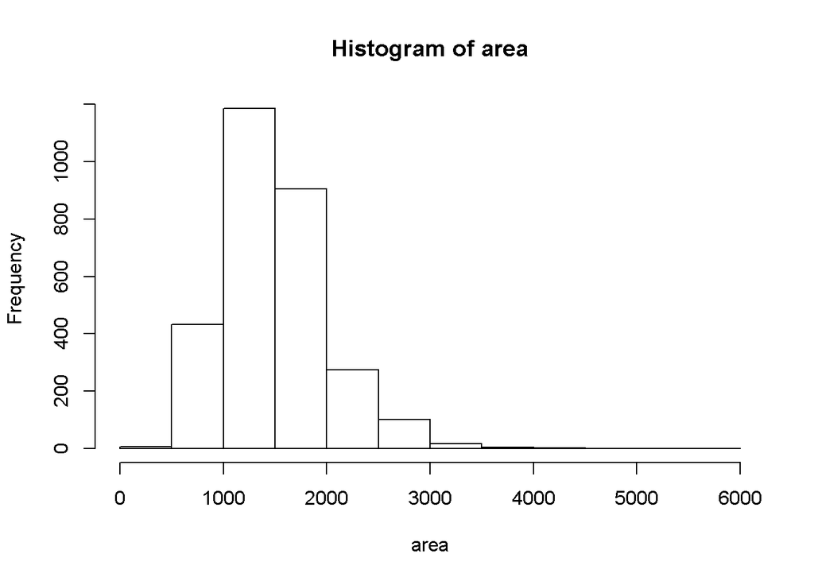

```r
hist(area)
```

**Exercise 1** Describe this population distribution.

```r
samp1 <- sample(area, 50)
```

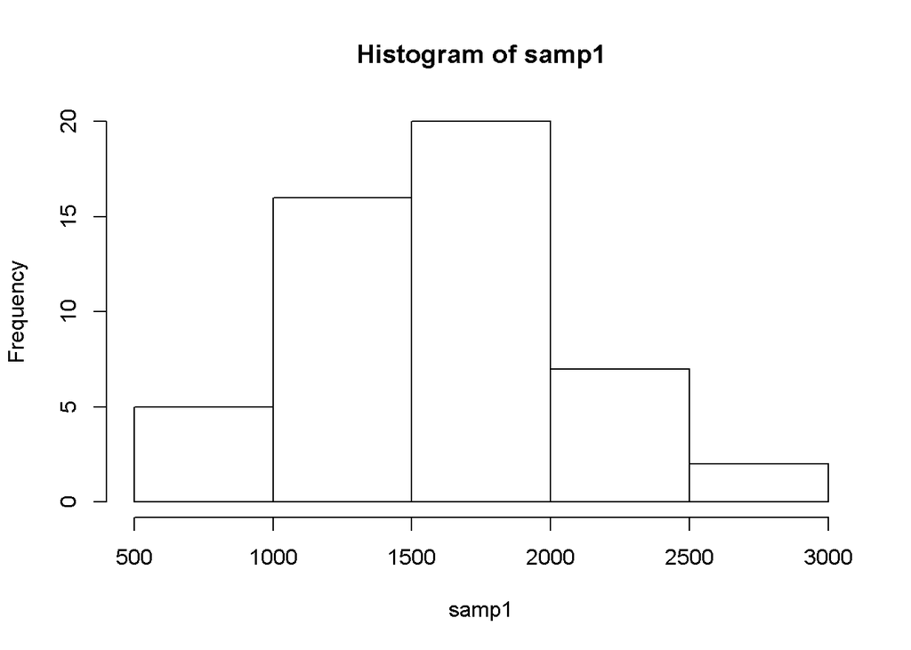

```r
hist(samp1)
```

**Exercise 2**

Describe the distribution of this sample. How does it compare to the distribution of the population?

```r
mean(samp1)
```

```
## [1] 1594.16
```

```r
summary(samp1)
```

```
##    Min. 1st Qu.  Median    Mean 3rd Qu.    Max.
##     756    1332    1583    1594    1728    2775
```

**Exercise 3** **Take a second sample, also of size 50, and call it samp2. How does the mean of samp2 compare with the mean of samp1? Suppose we took two more samples, one of size 100 and one of size 1000. Which would you think would provide a more accurate estimate of the population mean?**

## On your own

So far, we have only focused on estimating the mean living area in homes in Ames. Now you’ll try to estimate the mean home price.

**Exercise 1** Take a random sample of size 50 from price. Using this sample, what is your best point estimate of the population mean?

```r
samp_price <- sample(price, 50)
samp_priceMean <- mean(samp_price)
```

**Exercise 2** Since you have access to the population, simulate the sampling distribution for x¯price by taking 5000 samples from the population of size 50 and computing 5000 sample means. Store these means in a vector called sample_means50. Plot the data, then describe the shape of this sampling distribution. Based on this sampling distribution, what would you guess the mean home price of the population to be? Finally, calculate and report the population mean.

```r
sample_means50<-rep(0,5000)
for(i in 1:5000){
samp<-sample(price,50)
sample_means50[i]<-mean(samp)
}
```

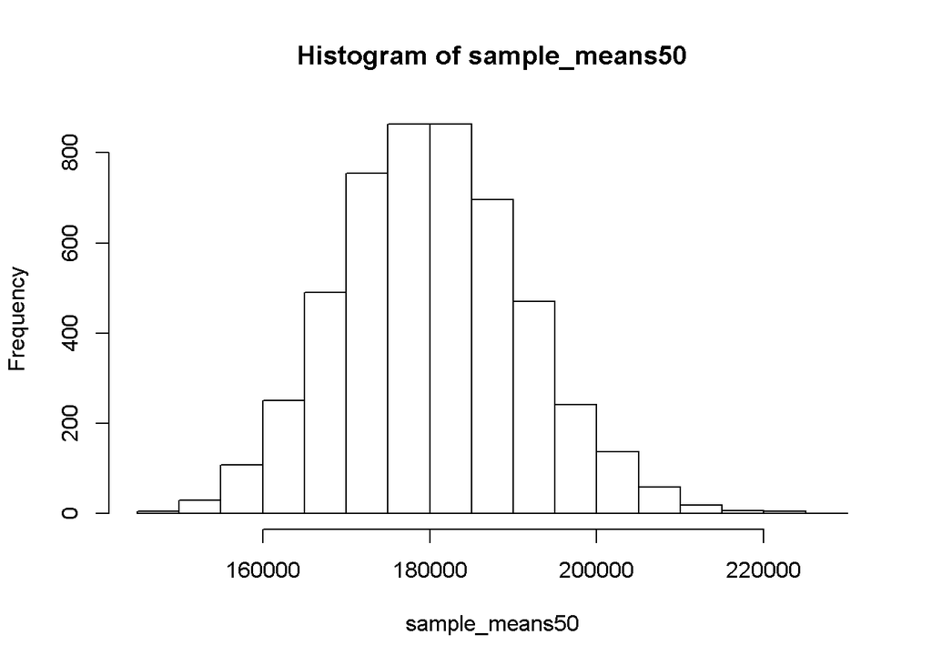

```r
hist(sample_means50, breaks = 25)
```

```r
summary(price)
```

```
##    Min. 1st Qu.  Median    Mean 3rd Qu.    Max.
##   12790  129500  160000  180800  213500  755000
```

```r
population_mean <- mean(sample_means50)
population_mean
```

```
## [1] 180365.5
```

**Exercise 3** Change your sample size from 50 to 150, then compute the sampling distribution using the same method as above, and store these means in a new vector called sample_means150. Describe the shape of this sampling distribution, and compare it to the sampling distribution for a sample size of 50. Based on this sampling distribution, what would you guess to be the mean sale price of homes in Ames?

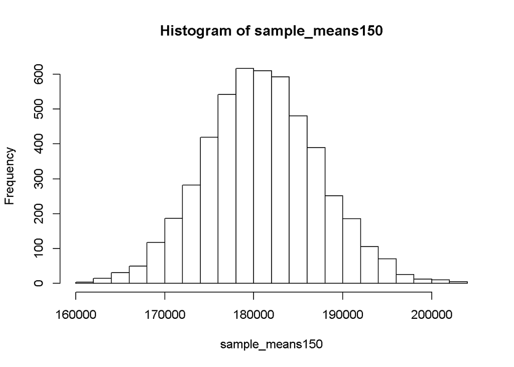

```r
sample_means150 <- rep(NA, 5000)

for(i in 1:5000){
   samp <- sample(price, 150)
   sample_means150[i] <- mean(samp)
   }

hist(sample_means150, breaks = 25)
```

**Exercise 4** Of the sampling distributions from 2 and 3, which has a smaller spread? If we’re concerned with making estimates that are more often close to the true value, would we prefer a distribution with a large or small spread?